# EasyVisa Project

#### Observations on region of employment

```
Skipping outlier analysis for region_of_employment as it contains string values.
```

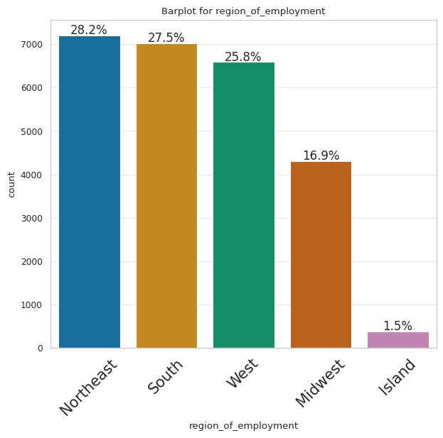

```python
labeled_barplot(data, "region_of_employment",  perc=True, rotation = 45)
```

#### Observations on adjusted yearly prevailing wage

This section was moved to the "Leading Question" section above to answer question #5

#### Observations on unit of wage

```
Skipping outlier analysis for unit_of_wage as it contains string values.
```

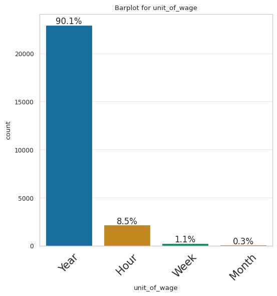

```python
labeled_barplot(data, "unit_of_wage",  perc=True, rotation = 45)
```

#### Obsevations on full time positions

```
Skipping outlier analysis for full_time_position as it contains string values.
```

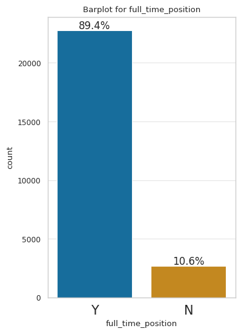

```python
labeled_barplot(data, "full_time_position",  perc=True, rotation = 0)
```

#### Observations on case status

```
Skipping outlier analysis for case_status as it contains string values.
```

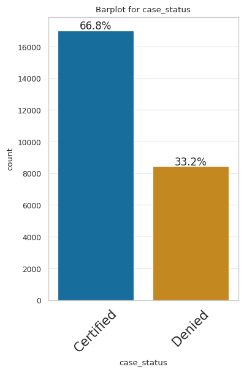

```python
labeled_barplot(data, "case_status",  perc=True, rotation = 45)
```

### Bivariate Analysis

#### Heatmap & Pairplot

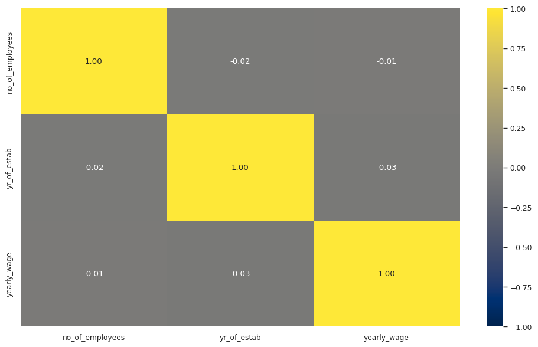

```python
cols_list = data.select_dtypes(include=np.number).columns.tolist()

plt.figure(figsize=(12, 7))
sns.heatmap(
    data[cols_list].corr(), annot=True, vmin=-1, vmax=1, fmt=".2f", cmap="cividis"
)
plt.show()
```

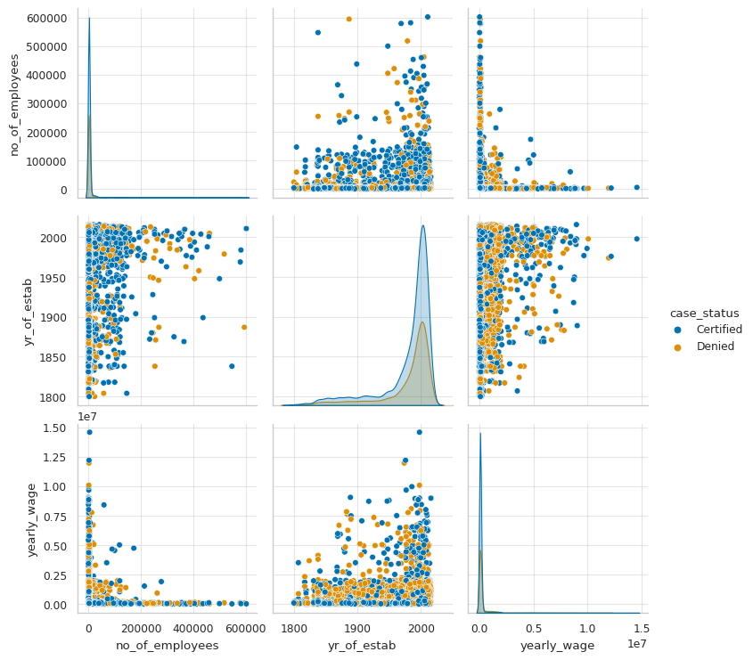

```python
pair_cols = ['no_of_employees','yr_of_estab','yearly_wage','case_status']
sns.pairplot(data = data[pair_cols], hue="case_status", diag_kind="kde", aspect=1)
```

```python
data.info()
```

```
<class 'pandas.core.frame.DataFrame'>
RangeIndex: 25480 entries, 0 to 25479
Data columns (total 11 columns):
 #   Column                 Non-Null Count  Dtype
---  ------                 --------------  -----
 0   continent              25480 non-null  category
 1   education_of_employee  25480 non-null  category
 2   has_job_experience     25480 non-null  category
 3   requires_job_training  25480 non-null  category
 4   no_of_employees        25480 non-null  int64
 5   yr_of_estab            25480 non-null  int64
 6   region_of_employment   25480 non-null  category
 7   unit_of_wage           25480 non-null  category
 8   full_time_position     25480 non-null  category
 9   case_status            25480 non-null  category
 10  yearly_wage            25480 non-null  float64
dtypes: category(8), float64(1), int64(2)
memory usage: 797.7 KB
```

No patterns here.

#### Target Variable Bivariate - case_status

Most of the relevant visualizations have been moved to the "Leading Questions" section above. Here are the two remaining:

```
case_status          Certified        Denied        Total
                             %      n      %     n      n
region_of_employment
Island                   60.27    226  39.73   149    375
Midwest                  75.53   3253  24.47  1054   4307
Northeast                 62.9   4526   37.1  2669   7195
South                    70.02   4913  29.98  2104   7017
West                     62.25   4100  37.75  2486   6586
Total                    66.79  17018  33.21  8462  25480
------------------------------------------------------------------------------------------------------------------------
```

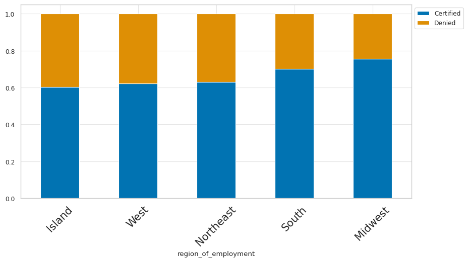

```python
stacked_barplot(data, 'region_of_employment', 'case_status',rotation = 45)
```

The Midwest has the highest Certification rate, but all regions are between 60% and 75% - not much variance.

```
case_status        Certified        Denied        Total
                           %      n      %     n      n
full_time_position
N                      68.53   1855  31.47   852   2707
Y                      66.58  15163  33.42  7610  22773
Total                  66.79  17018  33.21  8462  25480
------------------------------------------------------------------------------------------------------------------------
```

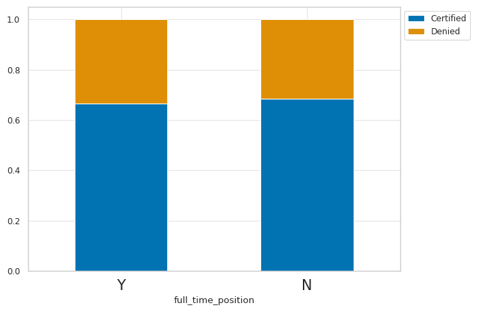

```python
stacked_barplot(data, 'full_time_position', 'case_status',rotation = 0)
```

Again, very little variance.

#### Observations on Employee Education and Training

```
has_job_experience         N         Total      Y
                           %      n      n      %      n
education_of_employee
Bachelor's             42.49   4348  10234  57.51   5886
Doctorate              42.93    941   2192  57.07   1251
High School            40.82   1396   3420  59.18   2024
Master's               41.45   3993   9634  58.55   5641
Total                  41.91  10678  25480  58.09  14802
------------------------------------------------------------------------------------------------------------------------
```

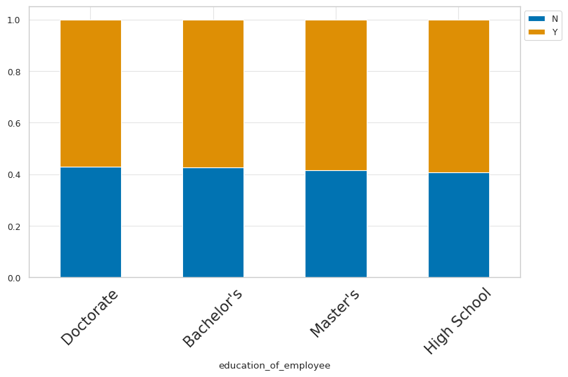

```python
stacked_barplot(data, 'education_of_employee', 'has_job_experience',rotation = 45)
```

```
unit_of_wage            Hour       Month      Total  Week        Year
                           %     n     %   n      n     %    n      %      n
education_of_employee
Bachelor's              9.59   981   0.4  41  10234  1.23  126  88.78   9086
Doctorate               4.38    96  0.23   5   2192  0.36    8  95.03   2083
High School            11.55   395  0.38  13   3420  0.94   32  87.13   2980
Master's                7.11   685  0.31  30   9634   1.1  106  91.48   8813
Total                   8.47  2157  0.35  89  25480  1.07  272  90.12  22962
------------------------------------------------------------------------------------------------------------------------
```

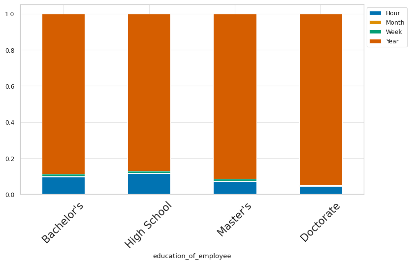

```python
stacked_barplot(data, 'education_of_employee', 'unit_of_wage',rotation = 45)
```

```
education_of_employee Bachelor's        Doctorate       High School       Master's        Total
                               %      n         %     n           %     n        %     n      n
continent
Africa                     25.95    143       9.8    54       11.98    66    52.27   288    551
Asia                       42.51   7168      5.47   923       13.58  2290    38.43  6480  16861
Europe                     34.81   1299     22.67   846       13.13   490    29.39  1097   3732
North America              37.21   1225      7.84   258       12.18   401    42.77  1408   3292
Oceania                    34.38     66     11.46    22       18.75    36    35.42    68    192
South America              39.08    333     10.45    89       16.08   137    34.39   293    852
Total                      40.16  10234       8.6  2192       13.42  3420    37.81  9634  25480
------------------------------------------------------------------------------------------------------------------------
```

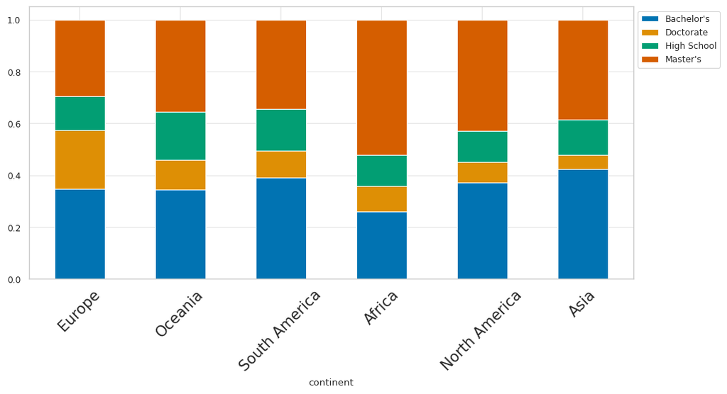

```python
stacked_barplot(data, 'continent', 'education_of_employee',rotation = 45)
```

Applicants from Africa have more Master's degrees than any other region. Applicants from Asia have more Bachelor;s degrees. Applicants from Europe have more Doctorate degree.

```
education_of_employee Bachelor's        Doctorate       High School       Master's        Total
                               %      n         %     n           %     n        %     n      n
region_of_employment
Island                      34.4    129      6.67    25        16.0    60    42.93   161    375
Midwest                    30.53   1315      5.94   256       17.09   736    46.44  2000   4307
Northeast                  39.94   2874      9.12   656       12.58   905    38.36  2760   7195
South                      42.63   2991      7.71   541       13.31   934    36.35  2551   7017
West                       44.41   2925     10.84   714       11.92   785    32.83  2162   6586
Total                      40.16  10234       8.6  2192       13.42  3420    37.81  9634  25480
------------------------------------------------------------------------------------------------------------------------
```

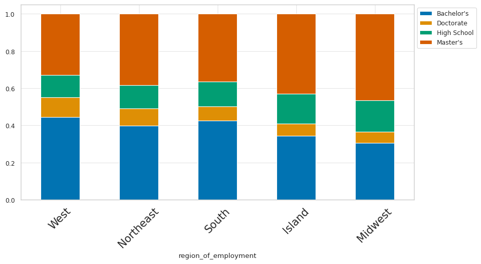

```python
stacked_barplot(data, 'region_of_employment', 'education_of_employee',rotation = 45)
```

```python
##convert to html snippet
%%shell
jupyter nbconvert --to html //content/DSBA_Project_ET_EasyVisa_Fullcode (2).ipynb
```

[output not shown]

[output not shown]